# Read counts summary

SYSTEM: R version 4.3.3 (2024-02-29)

DATE: 2024-09-13 12:52:32.886277

# 1 Requirements

- loading libraries `dplyr`, `ggplot2`, `tidyr`, `Hmisc`

# 2 Sample overview

## 2.1 Data import

- Checking if result file(s) are available:

| input_files | size | isdir | mode | mtime | uname |
| --- | --- | --- | --- | --- | --- |
| all_counts.tsv | 2.536486 MB | FALSE | 664 | 2024-09-13 12:49:21.303791 | ute |

- Importing result table(s):

```
[1] "Import of counts table complete."
```

# 3 Quality control

## 3.1 Total number of mapped reads per sample

- figure shows the total number of mapped reads used for fitness score calculation
- all other reads that were filtered out during preprocessing (low quality, low mapping score) are not included

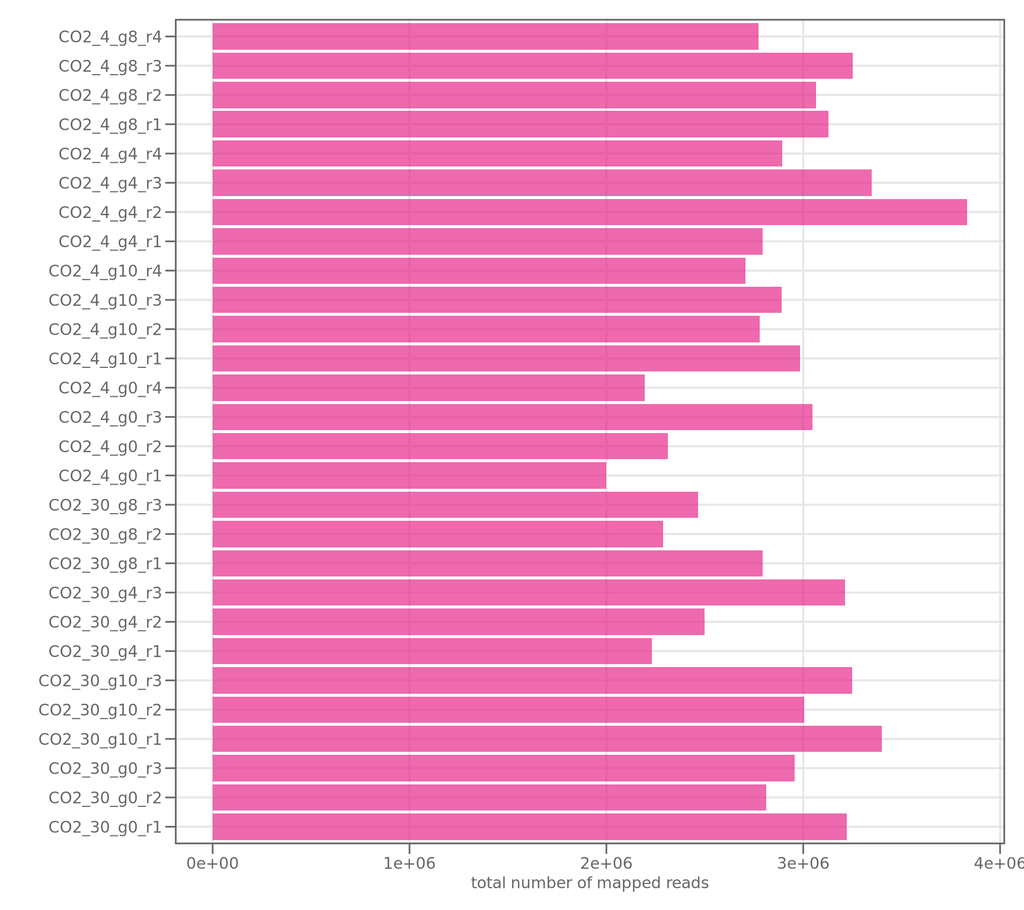

## 3.2 Number of individual barcodes per sample

- figure shows the number of individual, unique barcodes per sample
- depnding on `bowtie` settings, a certain number of mismatches in barcodes are allowed

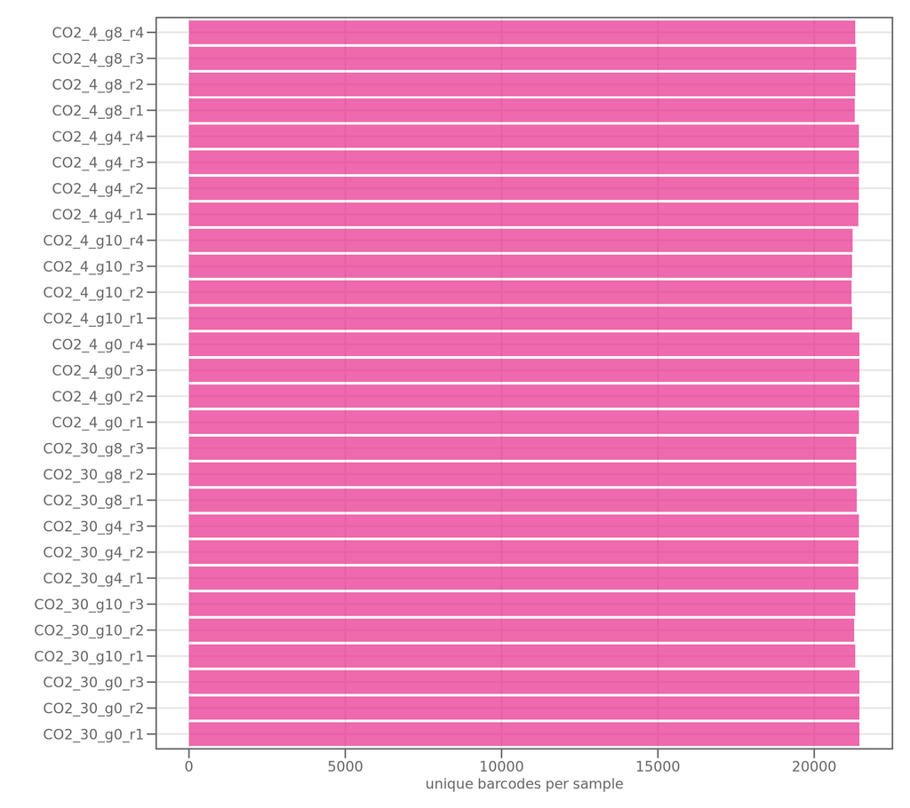

## 3.3 Number of missing barcodes per sample

- figure shows the number of missing barcodes per sample
- this number is determined from the number of total encountered barcodes across all samples

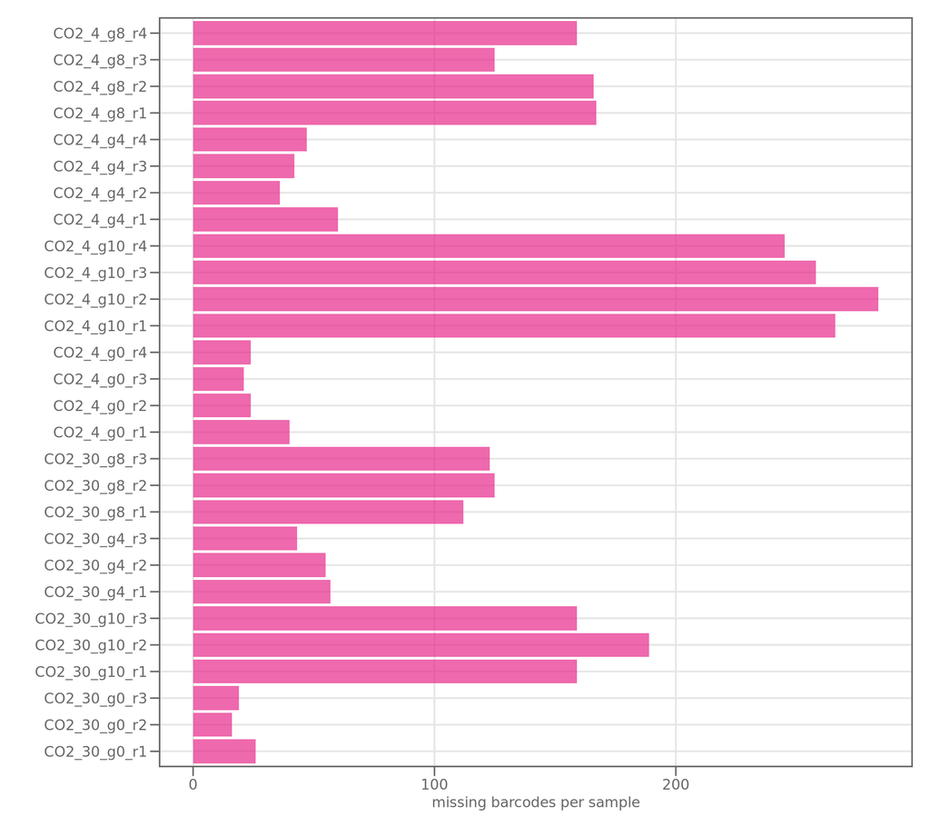

## 3.4 Number of barcodes per gene, per sample

- figure shows the number of barcodes per gene, per sample
- the x-axis shows the number of genes with N barcodes, broken down by sample
- barcodes without mapped reads for the respective sample are removed
- for example a colored bar with label `≤ 2` shows number of genes with less or equal than 2 barcodes

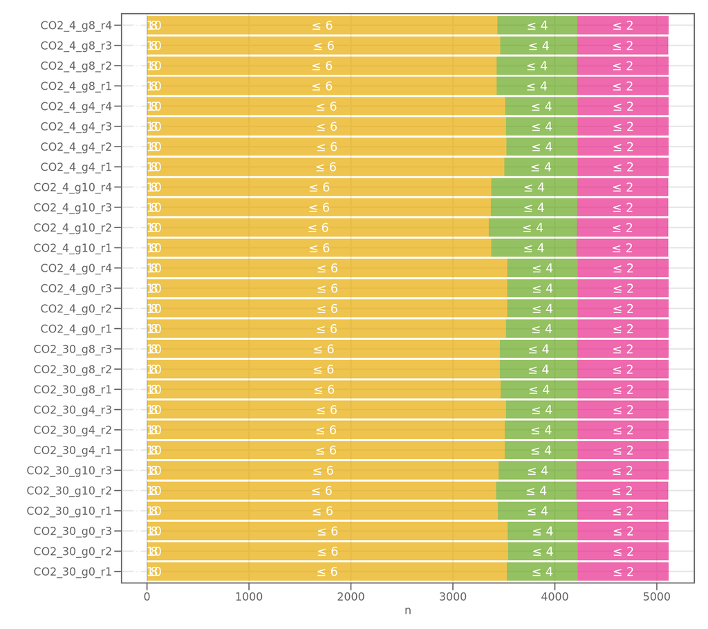

## 3.5 Read count distribution, violin plot

- figure shows the read count distribution per sample and barcode
- read count per barcode is only shown for the first 1000 barcodes to reduce processing time
- barcodes without mapped reads for the respective sample are removed
- read count is log 10 transformed (0 -> 1, 1 -> 10, 2 -> 100, …)

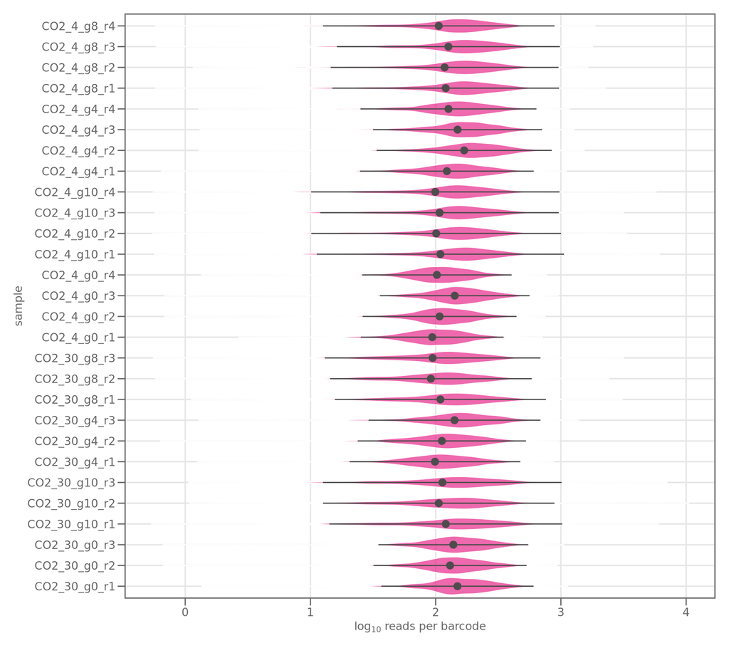

## 3.6 Read count distribution, histogram

- figure shows the same data as above, but with full set of barcodes per sample
- barcodes without mapped reads for the respective sample are removed
- read count is log 10 transformed (0 -> 1, 1 -> 10, 2 -> 100, …)

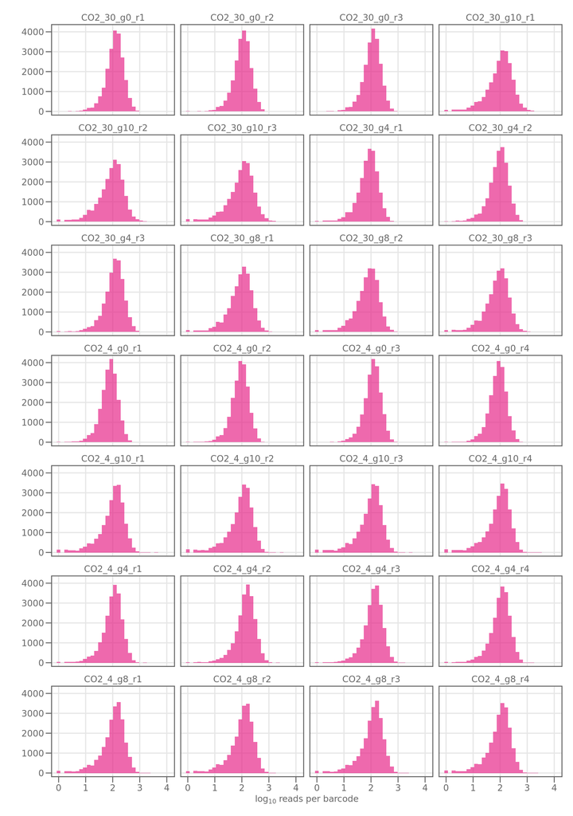

## 3.7 Top 10 most abundant barcodes, per sample

- figure shows top 10 barcodes ranked by read count
- ideally, initial time point samples show high equality of barcode abundance
- extremely high abundance of very few barcodes is a sign of few mutants outcompeting the population
- this can happen when libraries are (pre-) cultivated for too long periods of time
- can lead to downstream problems as it reduces library diversity (depletes low abundant mutants)

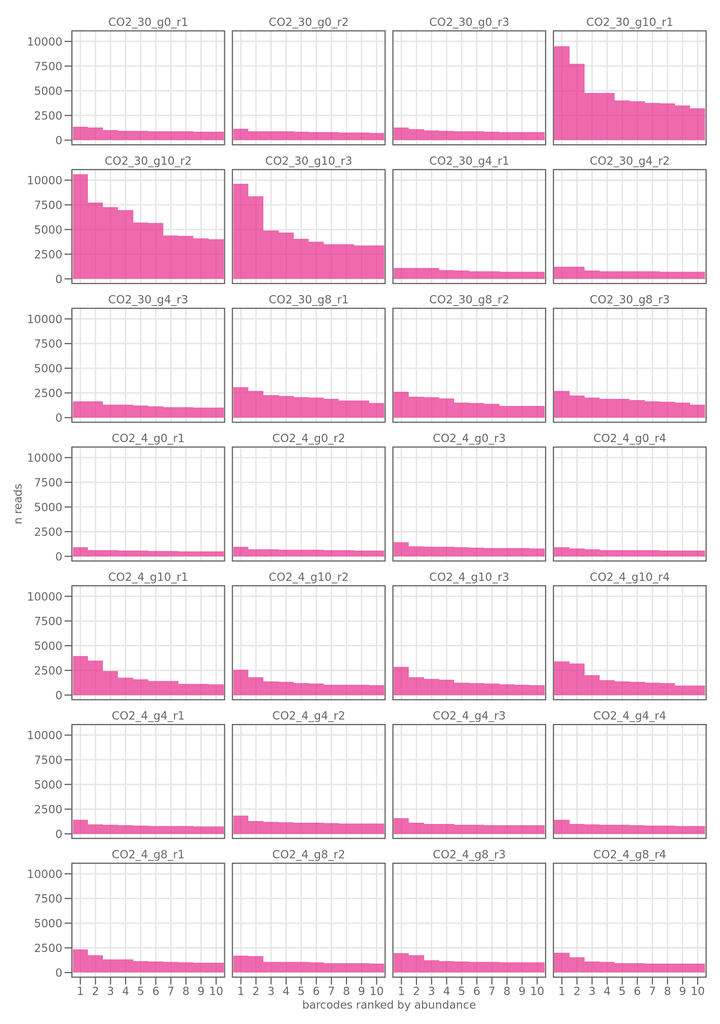

## 3.8 Cumulative read count distribution and barcode diversity

- figure shows the barcode diversity by plotting fraction of reads (%) vs fraction of barcodes (%)
- the ideal library has high diversity and equal distribution of barcodes for initial time points
- such a distribution would follow the diagonal dashed grey line
- if reads per barcode (red line) are not well distributed, `% of reads` (y-axis) shows a steep ascent
- this means very few barcodes contribute to almost all reads

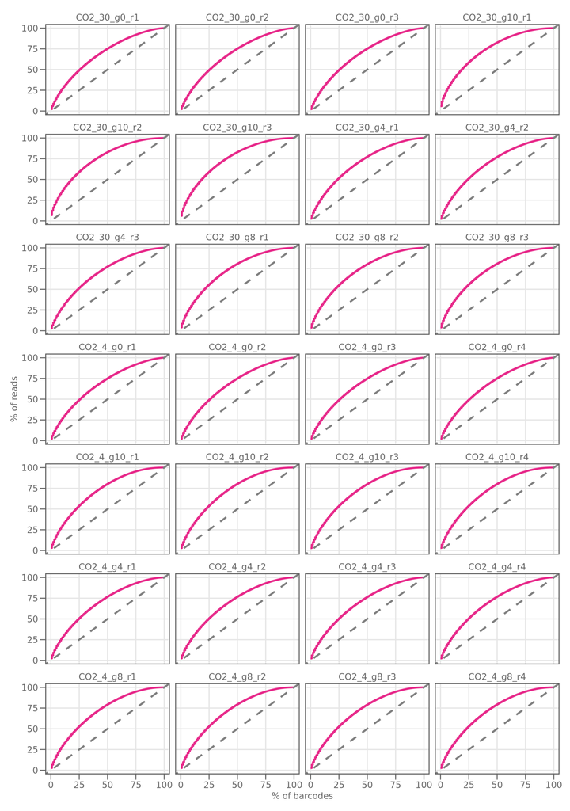

- this table shows the area under curve (AUC) for the line plot above
- an AUC of 0.5 is ideal, an AUC approaching 1.0 is not optimal
- the ‘Gini index’ is a score between 0 and 1 measuring population equality
- it is defined as the `(AUC - AUC_optimal) / AUC_optimal`
- a Gini score of 0 describes a perfectly equal, a Gini score of 1.0 a perfectly unequal distribution

| sample | auc | auc_optimal | gini | quality |
| --- | --- | --- | --- | --- |
| CO2_30_g0_r1 | 0.6873962 | 0.5 | 0.3747925 | intermediate inequality (0.33 < G < 0.66) |
| CO2_30_g0_r2 | 0.6876035 | 0.5 | 0.3752071 | intermediate inequality (0.33 < G < 0.66) |
| CO2_30_g0_r3 | 0.6875715 | 0.5 | 0.3751430 | intermediate inequality (0.33 < G < 0.66) |
| CO2_30_g10_r1 | 0.7479362 | 0.5 | 0.4958725 | intermediate inequality (0.33 < G < 0.66) |
| CO2_30_g10_r2 | 0.7509599 | 0.5 | 0.5019197 | intermediate inequality (0.33 < G < 0.66) |
| CO2_30_g10_r3 | 0.7505176 | 0.5 | 0.5010352 | intermediate inequality (0.33 < G < 0.66) |
| CO2_30_g4_r1 | 0.7034321 | 0.5 | 0.4068642 | intermediate inequality (0.33 < G < 0.66) |
| CO2_30_g4_r2 | 0.7009608 | 0.5 | 0.4019217 | intermediate inequality (0.33 < G < 0.66) |
| CO2_30_g4_r3 | 0.7033910 | 0.5 | 0.4067821 | intermediate inequality (0.33 < G < 0.66) |
| CO2_30_g8_r1 | 0.7296908 | 0.5 | 0.4593816 | intermediate inequality (0.33 < G < 0.66) |

[output cut: 18 more lines]

## 3.9 Sample and replicate correlation coefficent (R)

- figure shows heat map with correlation coefficient R (-1 < R < 1)
- correlation coefficient shows how strongly read abundance is correlated

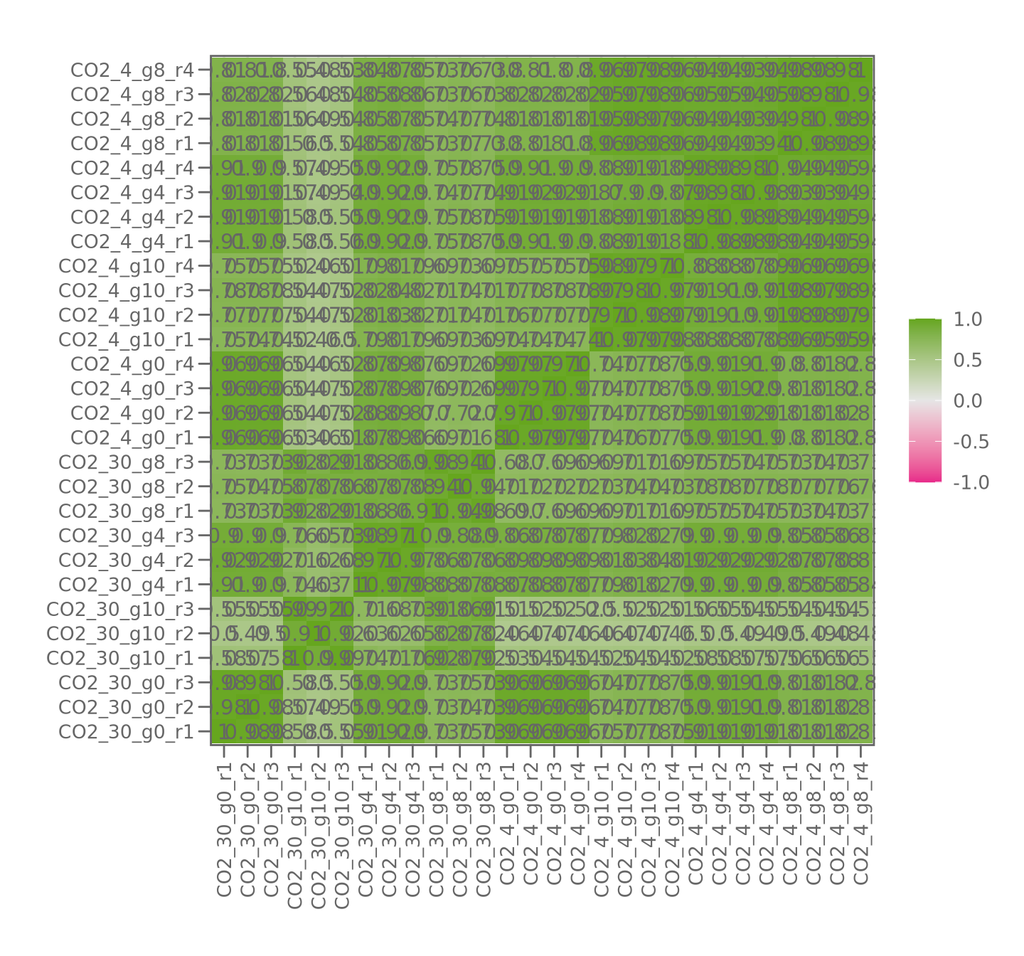

## 3.10 Sample and replicate similarity with PCA

- this figure shows sample similarity similar to above figure
- uses principal component analysis (PCA) to reduce the multidimensional data to 3 main dimensions
- plotted are principal component 1 (x-axis), 2 (y-axis) and 3 (point size)
- replicates for same samples should cluster together
- outliers should be easily visible

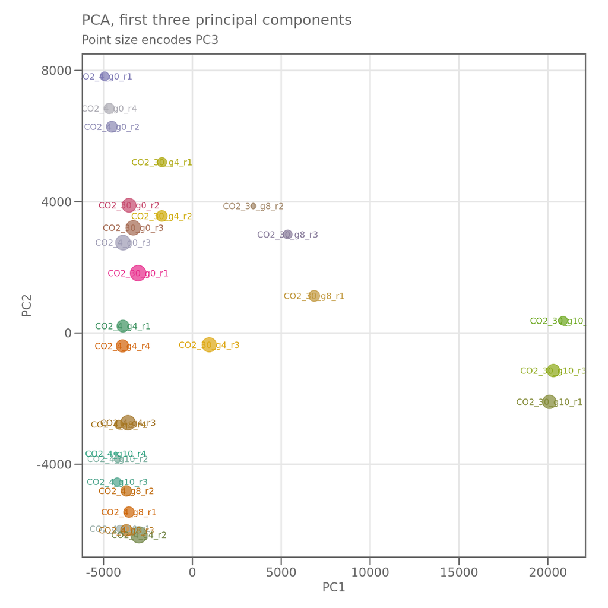

# 4 Report info

The template for this report is located in `./nf-core-crispriscreen/bin/counts_summary.Rmd`.

Date: 2024-04-10

Author: Michael Jahn, PhD

Affilations:

- Science For Life Laboratory (KTH), Stockholm, Sweden
- Max-Planck-Unit for the Science of Pathogens, Berlin, Germany